# Assignment 2

```python
# Script name: Assignment 2
# Purpose of script:  Introduction to the Simple Regression model and derivation from a research question to a Simple Regression Model.
# Author: Minh-Thy Tyler
# Date Created: 08/31/2022
# Notes:
# ---------------------------
#Packages
import os
import numpy as np
import matplotlib.pyplot as plt
import seaborn as sns
import pandas as pd

directory_path = '/Users/minh-thytyler/Desktop/2022-2023/ECON 320/HW/2' # use / instead of \ or use \ but insert r before (for instance: r'C:\your-directory-path')
os.chdir(directory_path)
```

**Part I**

```python
#Perform a data generating process of y = B0 + B1 * x + u
birthday = '08182001'
rng = np.random.RandomState(int(birthday))

beta0=9
beta1=8

x = rng.normal(loc=10,scale=1,size=1000000)
u = rng.normal(loc=0,scale=1,size=1000000)
y = beta0 +beta1*x +u

#data variable is in a data frame

data ={"x": x, "u":u,"y":y}
data = pd.DataFrame(data)
print(data.head())
print(data.describe())
```

```
           x         u          y
0  10.938747 -0.971789  95.538188
1   9.373442  0.025316  84.012853
2   9.834372 -0.255070  87.419905
3  10.289993 -0.549509  90.770432
4  10.603579  0.984107  94.812735
                    x               u               y
count  1000000.000000  1000000.000000  1000000.000000
mean         9.998355       -0.000556       88.986286
std          1.001314        1.001204        8.071350
min          5.170482       -4.927307       49.954255
25%          9.322126       -0.675628       83.540429
50%          9.998102       -0.001628       88.988615
75%         10.674147        0.674362       94.434029
max         15.224590        4.974452      130.354158
```

**Part II**

It looks like K would have a greater variance. Variance is defined as the average squared deviations from the mean. It reflects the variability in a distribution. The random variable K looks like it has more variabilitity in its observed values and has a greater range of numbers. K ranges from 4 to 19 and has many different inconsistant numbers. Wheras J ranges from 6 to 10 and its observed values hold greater consistentcy. All around, J has more values that are closer to its mean, and K does not have as many values that seem closer to its mean. Because of this, K looks like it would have greater variance.

*a) Find the SAMPLE variance for x and y*

```python
x = np.array([1,2,3,4,5,6,7,8,9,10])
y = np.array([5,7,8,8,10,12,11,15,19,18])
j = np.array([7,7,7,8,8,7,8,8,7,6,9,9,8,9,7,8,9,6,10,10,9])
k = np.array([18,16,15,16,10,11,11,9,11,19,8,8,6,4,9,10,7,15,10,7,5])

#finding means
meanx = x.mean()
meany = y.mean()

#Using sample variance formula
varx = ((x - meanx)**2).sum()/(len(x)-1)
vary = ((y - meany)**2).sum()/(len(y)-1)

print(f"varx: {varx}")
print(f"vary: {vary}")
```

[output not shown]

*b) Find SAMPLE cov(X,Y).*

```python
covxy = ((x-meanx)*(y-meany)).sum()/(len(x)-1)
print(f"covxy: {covxy}")
```

```
covxy: 13.722222222222221
```

*c) Find the sample var(J), sample var(K).*

```python
#finding means
meanj = j.mean()
meank = k.mean()

#Using sample variance formula
varj = ((j - meanj)**2).sum()/(len(j)-1)
vark = ((k - meank)**2).sum()/(len(k)-1)

print(f"varj: {varj}")
print(f"vark: {vark}")
```

```
varj: 1.3476190476190475
vark: 18.214285714285715
```

*d) Find sample cov(J,K).*

```python
covjk = ((j-meanj)*(k-meank)).sum()/(len(j)-1)
print(f"covjk: {covjk}")
```

```
covjk: -3.5642857142857154
```

*Present scatterplots of {X,Y} and {J,K}. Y and K should be on the vertical axes. Do not place any trend lines. Be sure to label axes.*

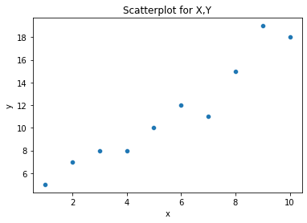

```python
sns.scatterplot(x= x, y=y)
plt.title("Scatterplot for X,Y")
plt.xlabel('x')
plt.ylabel('y')
```

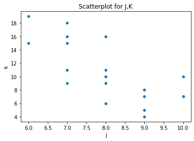

```python
sns.scatterplot(x= j, y=k)
plt.title('Scatterplot for J,K')
plt.xlabel('j')
plt.ylabel('k')
```